[figure not shown]

# Analysis of Steam Games

Jackson Styer

# Introduction:

Steam is a digital distribution service created by the Valve Corporation in 2003. When created, it was a simple software client that hosted Valve games, allowing them to provide automatic updates for their games while organizing them into one place. After proving to be an effective method of hosting and updating games, Steam’s popularity began to grow rapidly, leading to large publisher’s like [id Software](https://www.idsoftware.com/en-gb/), [Capcom](https://www.capcom.com/), and [Eidos Interactive](https://square-enix-games.com/en_US/home2) (now Square Enix) to begin distributing their games on the software in 2007.

As you can see from the graph below, the video game industry has been shifting from buying and selling physical video game content to buying and selling digital content. Steam’s platform played a major role in this worldwide change, as it became one of the most populated platforms on which to purchase digital copies of games. This growth led to Steam becoming the biggest digital distribution platform for PC games, holding 75% of the market space in 2013. Since that time it has grown even more, with users having spent around $4.3 billion purchasing games and content through Steam’s platform in 2017.

[figure not shown]

```python
from IPython.display import Image
#Source: https://arstechnica.com/gaming/2017/04/the-us-game-industry-is-a-lot-bigger-and-less-physical-than-we-thought/
Image(filename = "ptod.jpeg", width = 400, height = 100)
```

Steam also has a readily available API called [Steamworks](https://partner.steamgames.com/doc/api), which allows developers to integrate various Steam functions into their product. Take a look!

Today, Steam has over 34,000 games with around 95 million active users. This makes it a great place to learn and discover what games perform better than others and why, with metrics like sales, reviews, and time spent playing readily available to the public. Steam is also very supportive of smaller games created by independent developers, making it a space where I can accurately analyze all types of games, instead of a select group.

This information makes Steam a perfect candidate for a data science tutorial. All of this public unstructured data widely available paired with a platform that is rapidly growing and expanding in interesting ways makes data science the right medium in which to analyze this data.

This tutorial’s purpose is to explore this booming marketplace of video games and analyze what makes games outperform others in a multitude of metrics and why, as well as discovering certain trends and statistics that will hopefully lead to further insight and understanding of this industry as a whole.

# Data Collection

The first step in this analysis is collecting the relevant data. Below I load in two csv file's from data.world and kaggle that have information on over ten thousand steam games. You can take a look at them yourself to get a better understanding of the data I'll be working with, linked here: [data.world](https://data.world/craigkelly/steam-game-data/workspace/file?filename=games-features.csv) , [kaggle](https://www.kaggle.com/nikdavis/steam-store-games).  
I read both csv files into Panda's dataframes to be cleaned and manipulated for later analysis.  
If you are interested in the python libraries I used throughout this tutorial, here are some links for you to check out yourself:

- [Numpy](https://numpy.org/) (Mathematic functions)
- [Pandas](https://pandas.pydata.org/pandas-docs/stable/index.html) (Data Manipulation)
- [Matplotlib](https://matplotlib.org/) (For visualizations/plotting)
- [Seaborn](https://seaborn.pydata.org/) (Also for visualization, my personal favorite!)
- [IPython](https://ipython.org/) (Useful for Jupyter Notebooks)
- [re](https://docs.python.org/3/library/re.html) (Regex library for parsing data)

```python
import numpy as np
import pandas as pd
import matplotlib.pyplot as plt
import seaborn as sns
import re
import math
from math import exp, expm1
import warnings
warnings.filterwarnings('ignore')
```

```python
steam_df = pd.read_csv("games-features.csv")
steam2_df = pd.read_csv("steam.csv")
steam_df.head()
```

|  | QueryID | ResponseID | QueryName | ResponseName | ReleaseDate | RequiredAge | DemoCount | DeveloperCount | DLCCount | Metacritic | ... | LegalNotice | Reviews | SupportedLanguages | Website | PCMinReqsText | PCRecReqsText | LinuxMinReqsText | LinuxRecReqsText | MacMinReqsText | MacRecReqsText |
| --- | --- | --- | --- | --- | --- | --- | --- | --- | --- | --- | --- | --- | --- | --- | --- | --- | --- | --- | --- | --- | --- |
| 0 | 10 | 10 | Counter-Strike | Counter-Strike | Nov 1 2000 | 0 | 0 | 1 | 0 | 88 | ... |  |  | English French German Italian Spanish Simplifi... | None | Minimum: 500 mhz processor 96mb ram 16mb video... |  | Minimum: Linux Ubuntu 12.04 Dual-core from Int... |  | Minimum: OS X Snow Leopard 10.6.3 1GB RAM 4GB... |  |
| 1 | 20 | 20 | Team Fortress Classic | Team Fortress Classic | Apr 1 1999 | 0 | 0 | 1 | 0 | 0 | ... |  |  | English French German Italian Spanish | None | Minimum: 500 mhz processor 96mb ram 16mb video... |  | Minimum: Linux Ubuntu 12.04 Dual-core from Int... |  | Minimum: OS X Snow Leopard 10.6.3 1GB RAM 4GB... |  |
| 2 | 30 | 30 | Day of Defeat | Day of Defeat | May 1 2003 | 0 | 0 | 1 | 0 | 79 | ... |  |  | English French German Italian Spanish | http://www.dayofdefeat.com/ | Minimum: 500 mhz processor 96mb ram 16mb video... |  | Minimum: Linux Ubuntu 12.04 Dual-core from Int... |  | Minimum: OS X Snow Leopard 10.6.3 1GB RAM 4GB... |  |
| 3 | 40 | 40 | Deathmatch Classic | Deathmatch Classic | Jun 1 2001 | 0 | 0 | 1 | 0 | 0 | ... |  |  | English French German Italian Spanish | None | Minimum: 500 mhz processor 96mb ram 16mb video... |  | Minimum: Linux Ubuntu 12.04 Dual-core from Int... |  | Minimum: OS X Snow Leopard 10.6.3 1GB RAM 4GB... |  |
| 4 | 50 | 50 | Half-Life: Opposing Force | Half-Life: Opposing Force | Nov 1 1999 | 0 | 0 | 1 | 0 | 0 | ... |  |  | English French German Korean | None | Minimum: 500 mhz processor 96mb ram 16mb video... |  | Minimum: Linux Ubuntu 12.04 Dual-core from Int... |  | Minimum: OS X Snow Leopard 10.6.3 1GB RAM 4GB... |  |

5 rows × 78 columns

```python
steam_df.shape
```

```
(13357, 78)
```

Above is the messy data that I loaded in from 'games-features.csv'. From a brief glance we can see that many of the columns are contain data that is not relevant at all to the analysis I will be performing. We can also see that the shape of the dataframe is extremely large and needs to be refined into something that is more easily understandable. Time to clean!

# Data Tidying

Now that we have all of our data loaded in and ready to roll, it's time to tidy it up into something I can work with. Many of the columns aren't relevant at all to what I'm going to be looking at in the data, so we can get rid of these:

- QueryName: These values are the same as ResponseName so they need to be removed
- PackageCount/DemoCount/DeveloperCount: The second csv file I loaded in includes more accurate information on these columns, so I remove them from this table for now
- PriceCurrency: All values in this column are either USD or empty, and since we have a column that give's us information on the price this column is useless
- SupportEmail/SupportURL/DetailedDescrip/Website/SupportedLanguages are not relevant to the analysis I plan to perform, they are removed as well
- The PC requirement columns for the different operating systems are also removed, as many of the games do not have requirements and do not contribute to the later analysis

```python
#Drop columns that aren't relevant to analysis
steam_df = steam_df.drop(columns = ['QueryID' , 'ResponseID', 'QueryName', 'PackageCount', 'DemoCount', 'DeveloperCount',
                  'PackageCount', 'SupportEmail', 'SupportURL', 'DetailedDescrip', 'Website', 'SupportedLanguages',
                  'LegalNotice', 'Reviews', 'DRMNotice', 'ExtUserAcctNotice', 'HeaderImage', 'ScreenshotCount',
                  'PriceCurrency', 'PriceFinal', 'AboutText', 'Background', 'ShortDescrip', 'AchievementHighlightedCount',
                  'CategoryInAppPurchase', 'CategoryIncludeSrcSDK', 'CategoryIncludeLevelEditor', 'PCRecReqsText',
                  'LinuxRecReqsText', 'MacRecReqsText', 'PCReqsHaveMin', 'PCReqsHaveRec', 'LinuxReqsHaveMin',
                  'LinuxReqsHaveRec', 'MacReqsHaveMin', 'MacReqsHaveRec'])
```

```python
#Remove games that have less than 10,000 owners
steam_df = steam_df[steam_df.SteamSpyOwners > 10000]
```

Ideally when tidying data it would be best to condense all of separate columns for genre into one column with header 'Genre', and have the genre name listed for each game. However, many of these games belong to more than one genre, so for now I simply change all of the true/false values to 1's and 0's to ease later analysis on the data as well as make it much cleaner to view when looking directly at the table.  
Here is that step:

```python
#Here I change all of the true/false values for genre's into 1's and 0's
steam_df['GenreIsNonGame'] = steam_df['GenreIsNonGame']*1
steam_df['GenreIsIndie'] = steam_df['GenreIsIndie']*1
steam_df['GenreIsAction'] = steam_df['GenreIsAction']*1
steam_df['GenreIsAdventure'] = steam_df['GenreIsAdventure']*1
steam_df['GenreIsCasual'] = steam_df['GenreIsCasual']*1
steam_df['GenreIsStrategy'] = steam_df['GenreIsStrategy']*1
steam_df['GenreIsRPG'] = steam_df['GenreIsRPG']*1
steam_df['GenreIsSimulation'] = steam_df['GenreIsSimulation']*1
steam_df['GenreIsEarlyAccess'] = steam_df['GenreIsEarlyAccess']*1
steam_df['GenreIsFreeToPlay'] = steam_df['GenreIsFreeToPlay']*1
steam_df['GenreIsSports'] = steam_df['GenreIsSports']*1
steam_df['GenreIsRacing'] = steam_df['GenreIsRacing']*1
steam_df['GenreIsMassivelyMultiplayer'] = steam_df['GenreIsMassivelyMultiplayer']*1
steam_df['PlatformWindows'] = steam_df['PlatformWindows']*1
steam_df['PlatformLinux'] = steam_df['PlatformLinux']*1
steam_df['PlatformMac'] = steam_df['PlatformMac']*1
steam_df['ControllerSupport'] = steam_df['ControllerSupport']*1
steam_df['IsFree'] = steam_df['IsFree']*1
steam_df['FreeVerAvail'] = steam_df['FreeVerAvail']*1
steam_df['PurchaseAvail'] = steam_df['PurchaseAvail']*1
steam_df['SubscriptionAvail'] = steam_df['SubscriptionAvail']*1
steam_df['CategorySinglePlayer'] = steam_df['CategorySinglePlayer']*1
steam_df['CategoryMultiplayer'] = steam_df['CategoryMultiplayer']*1
steam_df['CategoryCoop'] = steam_df['CategoryCoop']*1
steam_df['CategoryMMO'] = steam_df['CategoryMMO']*1
steam_df['CategoryVRSupport'] = steam_df['CategoryVRSupport']*1
```

```python
#Rename column headers to ease readability
steam_df = steam_df.rename(columns={'GenreIsNonGame': 'NonGame', 'GenreIsIndie': 'Indie', 'GenreIsAction' :
                       'Action', 'GenreIsAdventure' : 'Adventure', 'GenreIsCasual' : 'Casual',
                       'GenreIsStrategy' : 'Strategy', 'GenreIsRPG' : 'RPG', 'GenreIsSimulation':
                       'Simulation', 'GenreIsEarlyAccess' : 'EarlyAccess', 'GenreIsFreeToPlay' :
                       'FreeToPlay', 'GenreIsSports' : 'Sports', 'GenreIsRacing' : 'Racing',
                       'GenreIsMassivelyMultiplayer' : 'MassivelyMultiplayer', 'ResponseName' :
                       'Title', 'CategorySinglePlayer' : 'SinglePlayer' , 'CategoryMultiPlayer' : 'MultiPlayer',
                        'CategoryCoop' : 'Co-op', 'CategoryVRSuport' : 'VRSupport'})
```

```python
pd.set_option("display.max_rows", None, "display.max_columns", None)
```

```python
#Replace cells that are empty wth NaN values in order to clean them further
steam_df = steam_df.replace(r'^\s*$', np.nan, regex=True)
#Remove rows where games have no minimum requirements for any platform
steam_df = steam_df.dropna(subset=['PCMinReqsText', 'LinuxMinReqsText', 'MacMinReqsText'], how='all')
```

```python
steam_df.shape
```

```
(6556, 43)
```

```python
#Reset the index
steam_df = steam_df.reset_index(drop=True)
#Rename column value in second pandas dataframe in order to merge with the first easily
steam2_df = steam2_df.rename(columns ={'name' : 'Title'})
#Merge the two dataframes with an inner merge where the Title's align.
cleaned_df = pd.merge(steam_df,steam2_df[['Title','positive_ratings', 'negative_ratings','median_playtime',
                                         'publisher', 'developer']], on='Title', how='inner')
```

```python
#Use regex to remove non-4 digit numbers from ReleaseDate column.
#This will make futher analysis+visualization easier
cleaned_df['ReleaseDate']=cleaned_df['ReleaseDate'].str.extract('(\d{4})')
#Drop rows where ReleaseDate is not available
cleaned_df.dropna(subset=['ReleaseDate'], how='all', inplace=True)
cleaned_df['ReleaseDate'] = cleaned_df['ReleaseDate'].astype(int)
```

```python
cleaned_df.head()
```

|  | Title | ReleaseDate | RequiredAge | DLCCount | Metacritic | MovieCount | RecommendationCount | PublisherCount | SteamSpyOwners | SteamSpyOwnersVariance | SteamSpyPlayersEstimate | SteamSpyPlayersVariance | AchievementCount | ControllerSupport | IsFree | FreeVerAvail | PurchaseAvail | SubscriptionAvail | PlatformWindows | PlatformLinux | PlatformMac | SinglePlayer | CategoryMultiplayer | Co-op | CategoryMMO | CategoryVRSupport | NonGame | Indie | Action | … |
| --- | --- | --- | --- | --- | --- | --- | --- | --- | --- | --- | --- | --- | --- | --- | --- | --- | --- | --- | --- | --- | --- | --- | --- | --- | --- | --- | --- | --- | --- | --- |
| 0 | Counter-Strike | 2000 | 0 | 0 | 88 | 0 | 68991 | 1 | 13033334 | 92789 | 9140731 | 78136 | 0 | 0 | 0 | 0 | 1 | 0 | 1 | 1 | 1 | 0 | 1 | 0 | 0 | 0 | 0 | 0 | 1 | … |
| 1 | Team Fortress Classic | 1999 | 0 | 0 | 0 | 0 | 2439 | 1 | 5399140 | 60368 | 753627 | 22699 | 0 | 0 | 0 | 0 | 1 | 0 | 1 | 1 | 1 | 0 | 1 | 0 | 0 | 0 | 0 | 0 | 1 | … |
| 2 | Day of Defeat | 2003 | 0 | 0 | 79 | 0 | 2319 | 1 | 7621102 | 71499 | 1709740 | 34145 | 0 | 0 | 0 | 0 | 1 | 0 | 1 | 1 | 1 | 0 | 1 | 0 | 0 | 0 | 0 | 0 | 1 | … |
| 3 | Deathmatch Classic | 2001 | 0 | 0 | 0 | 0 | 888 | 1 | 7498965 | 70936 | 789676 | 23235 | 0 | 0 | 0 | 0 | 1 | 0 | 1 | 1 | 1 | 0 | 1 | 0 | 0 | 0 | 0 | 0 | 1 | … |
| 4 | Half-Life: Opposing Force | 1999 | 0 | 0 | 0 | 0 | 2934 | 1 | 5399499 | 60370 | 705741 | 21968 | 0 | 0 | 0 | 0 | 1 | 0 | 1 | 1 | 1 | 1 | 1 | 0 | 0 | 0 | 0 | 0 | 1 | … |

# Visualization

Let's first take a look at the ten most owned games on Steam and see if we can learn anything from it. To do this I simply sort the data by # of owners in descending order, and remove all rows after the 10th. I include a bar graph showing the names and number of players for these games in order to make it easier to see any existing disparities

```python
top_ten = cleaned_df.sort_values('SteamSpyOwners', ascending=False)
top_ten = top_ten.drop(top_ten.index[10:4988])
```

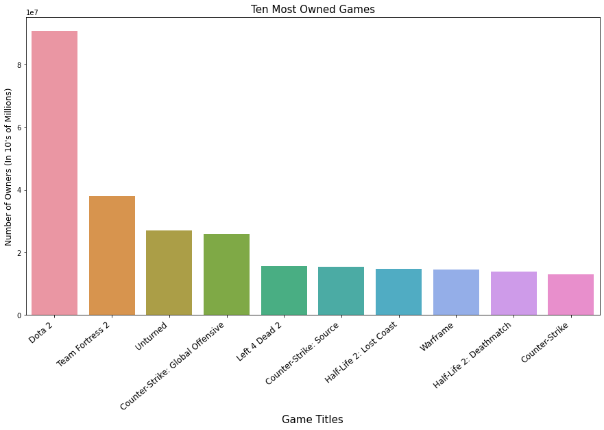

```python
plt.style.use('seaborn-pastel')
plt.figure(figsize=(15,8))
ax = sns.barplot(x="Title", y="SteamSpyOwners", data=top_ten)
ax.set_xticklabels(ax.get_xticklabels(), rotation=40, ha="right", fontsize = 12)
plt.xlabel("Game Titles", fontsize = 15)
plt.ylabel("Number of Owners (In 10's of Millions)", fontsize = 12)
plt.title("Ten Most Owned Games", fontsize = 15)
```

This plot may be of some interest to those who have heard of these games and are interested in their ownership relative to one another, however, it does not give us any real insight as to why these games have done so well.  
Some of these games are free to play, while others you have to purchase. In the plot above the three largest games are free, while most of the other's have to be purchased. This information tell's me that when looking at why specific games are popular later on in this tutorial, price will be a key factor that I have to consider.  
Let's now take a look at the developers and publishers of these games to see if there are any patterns or trends that we can observe.  
To do this I created two countplots below, that simply display the number of publishers and developers that appear within this restricted set of games

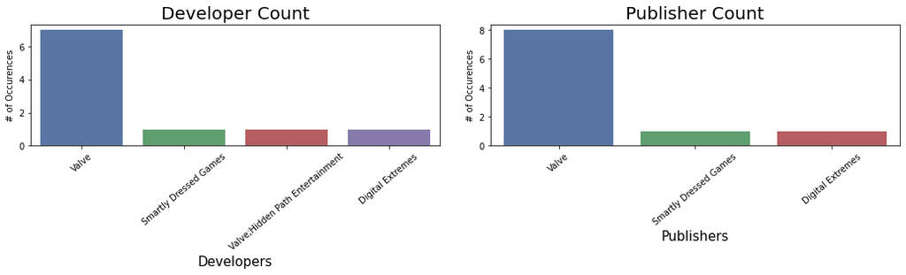

```python
plt.style.use('seaborn-deep')
fig, ax =plt.subplots(1,2, figsize = (15,5))
sns.countplot(top_ten['developer'], ax=ax[0])
sns.countplot(top_ten['publisher'], ax=ax[1])
for ax in fig.axes:
    plt.sca(ax)
    plt.xticks(rotation=40)
publisher_props = fig.axes[1]
publisher_props.set_title("Publisher Count", fontsize = 20)
publisher_props.set_xlabel("Publishers", fontsize = 15)
publisher_props.set_ylabel("# of Occurences")
developer_props = fig.axes[0]
developer_props.set_title("Developer Count", fontsize = 20)
developer_props.set_xlabel("Developers", fontsize = 15)
developer_props.set_ylabel("# of Occurences")
fig.tight_layout(pad=3.0)
```

Above you can see the number of times each developer and publisher appeared in the top ten games. As you can see, Valve has developed/published 70%/80% of the the top ten most owned games on this platform. This is to be expected due to the fact that Valve created Steam, and the software originally only had games created by Valve, giving them a head start on the flood of games that arrived in later years.

Now that we have looked at a sliver of the data representing only the biggest games, lets zoom out and look for notable trends or patterns of the dataset as a whole.  
To start off, lets take a look at Genre's on Steam to get a sense of the games and patterns that we will be analyzing. On Steam, games can be placed in a multitude of genres that accurately describe what is to be expected, instead of simply categorizing a game into one specific genre. To analyze this, I will find the total number of times that any given genre appears within my dataframe, and display it to get a better understanding.

```python
genres = cleaned_df[cleaned_df.columns[24:38]]
```

```python
cats = []
gen_sums = []
for i in genres.columns:
    cats.append(i)
    gen_sums.append(genres[i].sum())
    print(i, ":", genres[i].sum())
genre_totals = pd.DataFrame()
genre_totals['Genres'] = cats
genre_totals['Sums'] = gen_sums
```

```
CategoryMMO : 157
CategoryVRSupport : 97
NonGame : 29
Indie : 3066
Action : 2282
Adventure : 1696
Casual : 1226
Strategy : 1201
RPG : 912
Simulation : 803
EarlyAccess : 335
FreeToPlay : 435
Sports : 159
Racing : 195
```

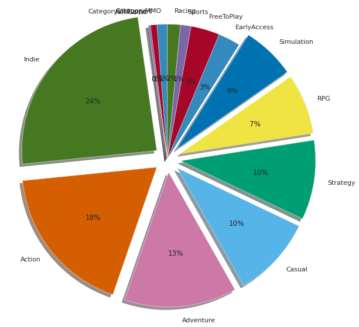

```python
labels = list(genre_totals.Genres.values)
fig1, ax1 = plt.subplots(figsize = (10,10))
explode = (0, 0, 0, 0.1, 0.1, 0.1, 0.1, 0.1, 0.1, 0.1, 0, 0, 0, 0)
ax1.pie(genre_totals['Sums'],explode = explode, labels=labels, autopct='%1.0f%%', shadow=True, startangle=90)
ax1.axis('equal')
plt.show()
```

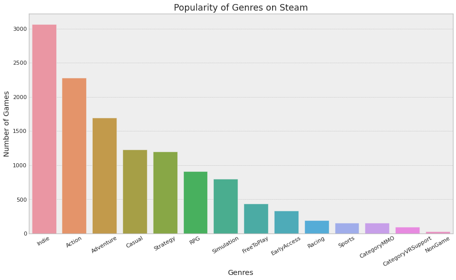

```python
bargenre = genre_totals.sort_values('Sums', ascending=False)
plt.figure(figsize=(15,8))
ax = sns.barplot(x="Genres", y="Sums", data=bargenre)
ax.set_xticklabels(labels = list(bargenre.Genres.values), rotation=30)
ax.set_ylabel('Number of Games')
ax.set_title('Popularity of Genres on Steam')
plt.show()
```

As you can see, the most common genre seen on Steam is Indie. This makes sense when considering Steam's approach to having games on their platform. When compared to other companies and their respective platform, getting a game to appear in their store is a much easier process. This leads to a large number of smaller, independently made games instead of what is generally seen on other platforms. For more information about this breakdown in regards to other platforms, take a look at this [website](https://www.researchgate.net/figure/Distribution-of-game-genres-for-leading-console-platforms-Notes-x360-Microsoft-Xbox_fig4_255995598) to see how my plot above compares.

It is also very important to understand that this distribution of genre's is not exactly representative of what games are the most popular or sucessful, and instead simply shows what genre of games are most commonly found in Steam's online store.

In order to learn more about what factors are important when looking at why certain games are so popular, lets take a look at some other metrics measured against Time (Release Date) on the x-axis, and see what we can uncover!  
Here are the next set of plots that help us observe these specific metrics against time:

- Number of game owners vs. Release Date
- Median playtime vs. Release Date
- Metacritic Score vs. Release Date
- Number of positive reviews vs. Release Date
- Number of negative reviews vs. Release Date
- Rating based off positive/negative Reviews vs. Release year (Explained under later plot)

Before we plot these relationships, it's important to get some context. To do this, I will first make a countplot that shows the number of games released each year. This additional information will hopefully further our understanding of the graphs to come, with the number of games released each year heavily impacting the relationship between Year and the various metrics I plot against it.

Below is the code and corresponding plot for each of these bullets, as well as the aforementioned contextual plot:

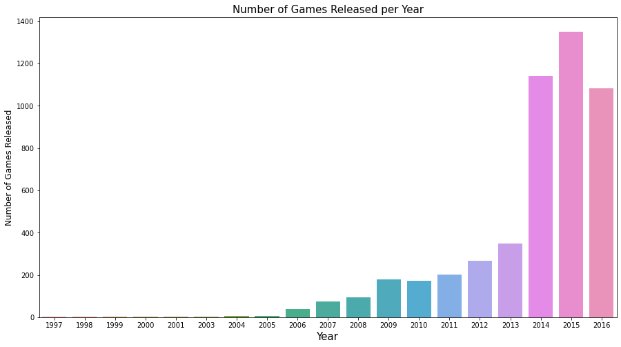

```python
by_year = cleaned_df.sort_values('ReleaseDate', ascending=True)
plt.figure(figsize=(15,8))
ax = sns.countplot(by_year['ReleaseDate'])
plt.xlabel("Year", fontsize = 15)
plt.ylabel("Number of Games Released", fontsize = 12)
plt.title("Number of Games Released per Year", fontsize = 15)
```

The plot above displays the number of games released each year, which will be relevant to the upcoming plots. As you can see their is a huge jump in volume from the year 2013 to 2014 making the next scatterplots extremely dense near the right hand side (later years) and quite sparse near the left hand side (older years).

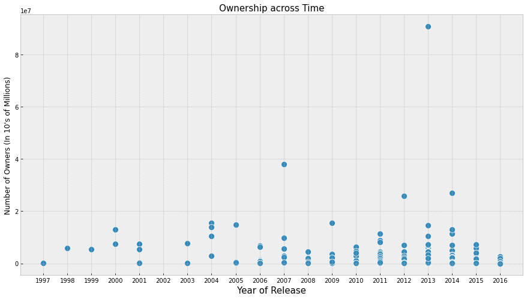

```python
plt.style.use('bmh')
plt.figure(figsize=(15,8))
sns.scatterplot(data=by_year, x="ReleaseDate", y="SteamSpyOwners", s = 100)
x_ticks = np.arange(1997, 2017, 1)
plt.xticks(x_ticks)
plt.xlabel("Year of Release", fontsize = 15)
plt.ylabel("Number of Owners (In 10's of Millions)", fontsize = 12)
plt.title("Ownership across Time", fontsize = 15)
```

```python
by_playtime = cleaned_df.sort_values('median_playtime', ascending=False)
by_playtime = by_playtime.reset_index(drop=True)
by_playtime = by_playtime.drop(by_playtime.index[0:3])
by_year_playtime = by_playtime.sort_values('ReleaseDate', ascending = True)
```

[figure not shown]

```python
plt.style.use('bmh')
plt.figure(figsize=(15,8))
sns.scatterplot(data=by_year_playtime, x="ReleaseDate", y="median_playtime", s = 100)
x_ticks = np.arange(1997, 2017, 1)
plt.xticks(x_ticks)
plt.xlabel("Year of Release", fontsize = 15)
plt.ylabel("Number of Owners (In 10's of Millions)", fontsize = 12)
plt.title("Median Playtime across Time", fontsize = 15)
```

Below I have plotted Metacritic score against the Date the game was released. Metacritic is a company that reviews games, tv shows, movies etc. and gives them a subjective rating between 1-100. Many games aren't big enough to be recognized and reviewed by Metacritic, and in the data I am using these games are simply given a score of 0 instead of a NaN value. Because of this, I created a new dataframe in the cell below that doesn't include games with a score of 0 which I then used for plotting in the next step.

```python
#Remove all rows with a metacritic score of 0
cleaned_score = by_year[by_year.Metacritic > 0]
```

[figure not shown]

```python
plt.style.use('bmh')
plt.figure(figsize=(15,8))
sns.scatterplot(data=cleaned_score, x="ReleaseDate", y="Metacritic", s = 100)
x_ticks = np.arange(1997, 2017, 1)
plt.xticks(x_ticks)
plt.xlabel("Year of Release", fontsize = 15)
plt.ylabel("Metacritic Score", fontsize = 12)
plt.title("Metacritic Scores across time", fontsize = 15)
```

Above you can see that there is no obvious correlation between year of release and metacritic score. Now that we have visualized it, lets take a look at a different metric of scoring games.  
Steam Users can review games through Steam's own platform, and the dataframe that I have cleaned contains these reviews. Each game has corresponding column headers relating to the number of positive reviews, as well as the number of negative reviews. Now let's take a look at the total number of each for all games as a whole, and then break it down based on the release year and see what we find!

```python
#Total number of positive reviews, negative reviews, and sum of each
total_pos = 0
total_neg = 0
for i in cleaned_df.positive_ratings:
    total_pos = total_pos + i
for j in cleaned_df.negative_ratings:
    total_neg = total_neg + j
total_sum = total_neg + total_pos
print(total_sum,  total_pos,  total_neg)
```

```
21484887 18302825 3182062
```

The readout above isn't that nice to look at, I'll make a pie chart to put these numbers in perspective

```python
ratings = cleaned_df[['positive_ratings', 'negative_ratings']]
ratings['pos_sum'] = ratings.positive_ratings.sum()
ratings['neg_sum'] = ratings.negative_ratings.sum()
ratings = ratings.drop(columns = ['positive_ratings' , 'negative_ratings'])
ratings_T = ratings.transpose()
ratings_T.drop(ratings_T.iloc[:, 1:4987], inplace = True, axis = 1)
```

The above code sums up the total positive and negative reviews, and then removes unnecessary information before I transpose the dataframe so it can be properly used for a pie chart.

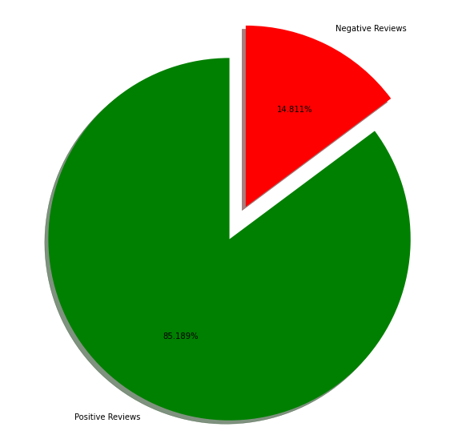

```python
labels = 'Positive Reviews' , 'Negative Reviews'
colors = ['green', 'red']
explode = (0, 0.2)
fig1, ax1 = plt.subplots(figsize = (10,10))
ax1.pie(ratings_T[0], explode=explode, labels=labels, colors = colors, autopct='%1.3f%%', shadow=True, startangle=90)
ax1.axis('equal')
plt.show()
```

Now we can more clearly see the difference between positive and negative reviews for Steam users as a whole. From the 21,484,887 ratings I had in my dataframe only 3.182,062 (14.811%) of them are negative, represented by the red slice above.  
It's fairly interesting that the vast majority of these ratings are positive, and may have something to do with my cleaning process. Since I removed games that have <10,000 owners, I may have avoided many games that recieved a large number of negative ratings.  
Let's now take a look at positive vs negative reviews per year. I'll do this by first summing both the total negative and total positive reviews per year, and plotting these values across time.

```python
year_ratings = cleaned_df.groupby('ReleaseDate')['positive_ratings', 'negative_ratings'].sum()
year_ratings.head() #Here we have what we need!
```

| ReleaseDate | positive_ratings | negative_ratings |
| --- | --- | --- |
| 1997 | 352 | 35 |
| 1998 | 27755 | 1100 |
| 1999 | 8568 | 921 |
| 2000 | 127292 | 4023 |
| 2001 | 8759 | 1227 |

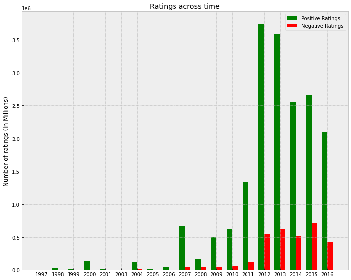

```python
plt.style.use('bmh')
labels = list(year_ratings.index.values)
x = np.arange(len(labels))
width = 0.35
fig, ax = plt.subplots(figsize = (10,8))
rects1 = ax.bar(x - width/2, year_ratings.positive_ratings,
                 width, color = 'green', label='Positive Ratings')
rects2 = ax.bar(x + width/2, year_ratings.negative_ratings,
                width, color = 'red', label='Negative Ratings')
ax.set_ylabel('Number of ratings (In Millions)')
ax.set_title('Ratings across time')
ax.set_xticks(x)
ax.set_xticklabels(labels)
ax.legend()
fig.tight_layout()
plt.show()
```

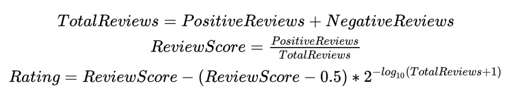

```python
year_ratings['TotalReviews'] = year_ratings['positive_ratings']+year_ratings['negative_ratings']
year_ratings['ReviewScore'] = year_ratings['positive_ratings']/year_ratings['negative_ratings']
all_ratings =[]
year = []
for i in year_ratings.index:
    score = year_ratings['ReviewScore'][i] - (year_ratings['ReviewScore'][i] -.5)* \
            2**-math.log10(year_ratings['TotalReviews'][i] + 1)
    all_ratings.append(score)
    year.append(i)
year_ratings['Rating'] = all_ratings
year_ratings['Year'] = year
```

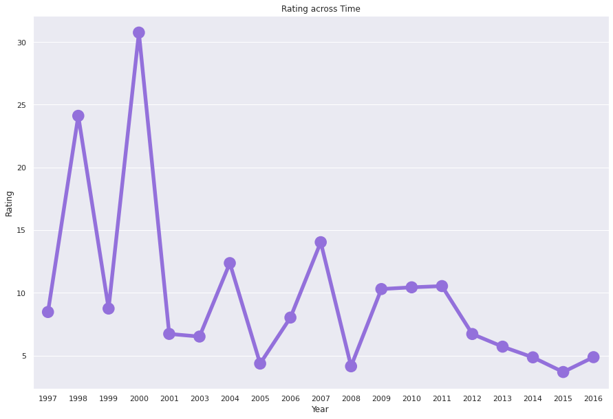

```python
sns.set_style("whitegrid")
sns.set(rc={"lines.linewidth": 3.0})
labels = list(year_ratings.index.values)
x = np.arange(len(labels))
fig, ax = plt.subplots(figsize=(15,10))
plot = sns.pointplot(ax = ax, data=year_ratings, x="Year", y="Rating", color = 'mediumpurple')
plot.set_title("Rating across Time")
```

The plot above was surprising to me, as I did not expect to see a decrease in rating as the years progressed. I suspect that this has something to do with the amount of ratings given each year. In the previous plot, we can see that the early years (1997-2006) had significantly less total ratings than the years after. This means that even if they don't have as many positive reviews in early years compared to later years, the ratio between positive and negative reviews was much higher than it was in later years.

Now that we taken a look at various metrics measured across Release Year, lets see what happends when observing these same metrics based on something I believe to be extremely important when looking at the success of games...the price.  
I'll first take a look at the average price of games for each year, and then perform a similiar set of plots as seen above, with price being the unit these various metrics are measured against instead of year.

```python
year_price = cleaned_df.groupby('ReleaseDate')['PriceInitial', 'DLCCount'].mean()
yearlist = list(year_price.index.values)
year_price['Year'] = yearlist
```

Above I have grouped the mean price and mean number of DLC's by year in order to create my next visualization.

For those that are unaware, DLC stands for (d)own(l)oadable (c)ontent. This is extra content for already released games that usually requires an additional purchase, though a few publishers release it for free. I chose to include the mean number of DLCs that were released every year in addition to the mean price of games per year, because I thought their might be some interesting correlations.

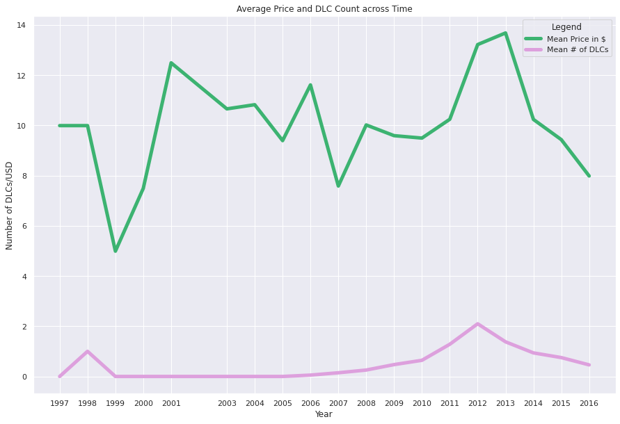

```python
sns.set_style('darkgrid')
sns.set(rc={"lines.linewidth": 5.0})
x = list(year_price.index.values)
fig, ax = plt.subplots(figsize = (15,10))
sns.lineplot(ax = ax, data=year_price, x="Year", y="PriceInitial",
                      color = 'mediumseagreen', label = 'Mean Price in $')
sns.lineplot(ax = ax, data=year_price, x="Year", y="DLCCount",
                      color = 'plum', label = 'Mean # of DLCs')
ax.set_title('Average Price and DLC Count across Time')
ax.set_ylabel('Number of DLCs/USD')
ax.legend(title = 'Legend')
ax.set(xticks=x)
plt.show()
```

This graph shows that the mean price of games per year has never risen above $14 between 1997-2016. It is also interesting to see that the significant increase in price from 2010 to 2012 aligns with the increase in number of DLC's released that year. In addition to that, there is another similarity in trend between the years 1998-1999 and 2013-2016, where both the mean price and dlc count decreased sharply.

With that done, lets move on to looking at the price against different metrics as done above with release date.

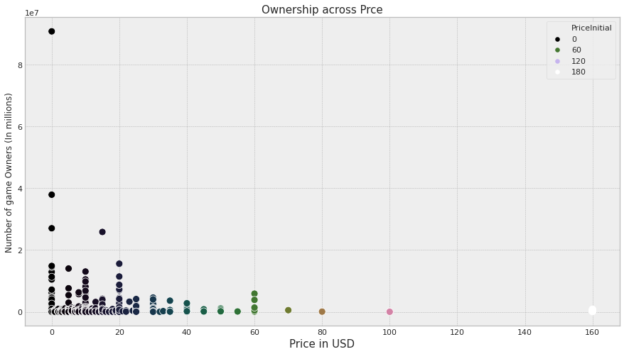

```python
by_price = cleaned_df.sort_values('PriceInitial', ascending=True)
plt.style.use('bmh')
plt.figure(figsize=(15,8))
sns.scatterplot(data=by_price, x="PriceInitial", y="SteamSpyOwners"
                , s = 100, hue = 'PriceInitial', palette = 'cubehelix')
plt.xlabel("Price in USD", fontsize = 15)
plt.ylabel("Number of game Owners (In millions)", fontsize = 12)
plt.title("Ownership across Prce", fontsize = 15)
plt.show()
```

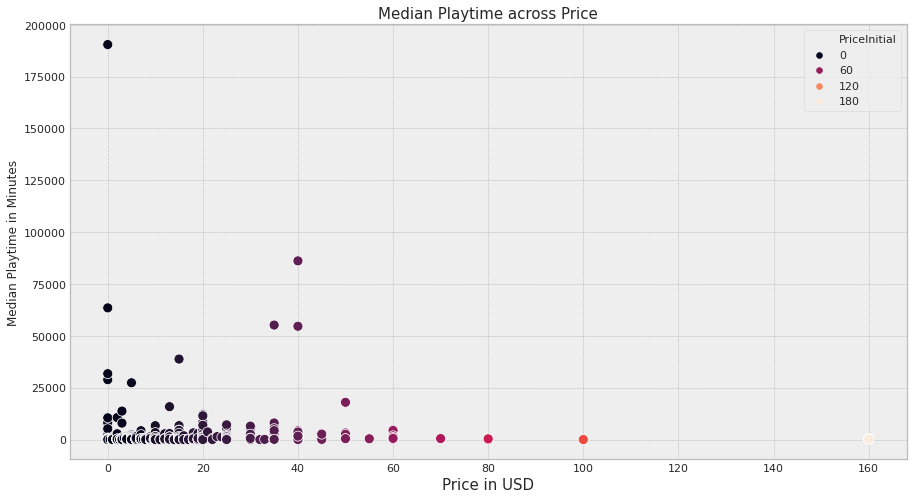

```python
plt.style.use('bmh')
plt.figure(figsize=(15,8))
sns.scatterplot(data=by_price, x="PriceInitial", y="median_playtime" ,
                s = 100, hue = 'PriceInitial', palette = 'rocket')
plt.xlabel("Price in USD", fontsize = 15)
plt.ylabel("Median Playtime in Minutes", fontsize = 12)
plt.title("Median Playtime across Price", fontsize = 15)
plt.show()
```

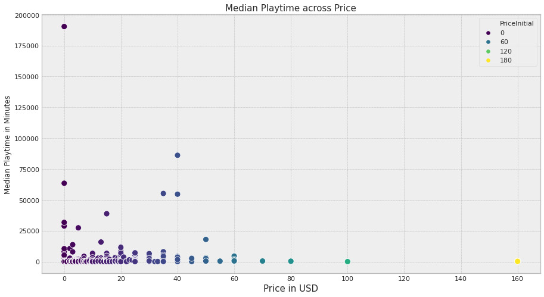

```python
plt.style.use('bmh')
plt.figure(figsize=(15,8))
sns.scatterplot(data=by_price, x="PriceInitial", y="median_playtime"
                , s = 100, hue = "PriceInitial", palette = 'viridis')
plt.xlabel("Price in USD", fontsize = 15)
plt.ylabel("Median Playtime in Minutes", fontsize = 12)
plt.title("Median Playtime across Price", fontsize = 15)
plt.show()
```

[figure not shown]

```python
cleaned_price = by_price[by_price.Metacritic > 0]
plt.style.use('bmh')
plt.figure(figsize=(15,8))
sns.scatterplot(data=cleaned_price, x="PriceInitial", y="Metacritic"
                , s = 100, hue = "PriceInitial", palette = "Spectral")
plt.xlabel("Price in USD", fontsize = 15)
plt.ylabel("Median Playtime in Minutes", fontsize = 12)
plt.title("Median Playtime across Price", fontsize = 15)
plt.show()
```

```python
import io
import os
from nbformat import current

total_markdown = 0
total_heading = 0
total_code = 0

for root, dirs, files in os.walk("."):
    for file in files:
        if file.endswith(".ipynb") and not file.endswith("checkpoint.ipynb") :
            #print(os.path.join(root, file))
            with io.open(os.path.join(root, file), 'r', encoding='utf-8') as f:
                nb = current.read(f, 'json')

            word_count_markdown = 0
            word_count_heading = 0
            word_count_code = 0
            for cell in nb.worksheets[0].cells:
                if cell.cell_type == "markdown":
                    word_count_markdown += len(cell['source'].replace('#', '').lstrip().split(' '))
                elif cell.cell_type == "heading":
                    word_count_heading += len(cell['source'].replace('#', '').lstrip().split(' '))
                elif cell.cell_type == "code":
                    word_count_code += len(cell['input'].replace('#', '').lstrip().split(' '))
            total_markdown += word_count_markdown
            total_heading += word_count_heading
            total_code += word_count_code

print("{} Words in notebooks' markdown" .format(total_markdown))
print("{} Words in notebooks' heading" .format(total_heading))
print("{} Words in notebooks' code" .format(total_code))
```

```
3574 Words in notebooks' markdown
125 Words in notebooks' heading
3699 Words in notebooks' code
```